# SVM Classification Project

# Pavan Kishore Kota Subramanya, ID: 2021AIML524

Welcome to SVM Classification Project! Go ahead and just follow the directions below.

classify tumors into malignant (cancer) or benign using features obtained from several cell images.

Features are computed from a digitized image of a fine needle aspirate (FNA) of a breast mass. They describe characteristics of the cell nuclei present in the image.

# 1.0 Environment setup

```python
# Convert jupyter notebook into full screen
from IPython.core.display import display, HTML
display(HTML("<style>.container { width:100% !important; }</style>"))

# Reset all variables and objects in notebook
%reset -f
```

# 2.0 Confirming the working directory

```python
from os import chdir, getcwd
wd = getcwd()
wd
```

```
'C:\\Users\\Pavan Kota\\Python\\Jupyter Notebooks'
```

# 3.0 Import Libraries

**Import pandas,seaborn, and the usual libraries.**

```python
from chefboost import Chefboost as chef

# for loading dataset
from dataprep.datasets import load_dataset
# importing function from DataPrep.eda
from dataprep.eda import create_report

import dalex as dx

from datetime import datetime

from genetic_selection import GeneticSelectionCV
import graphviz

#Import data from your laptop's local folder
from imblearn.over_sampling import SMOTE
from imblearn.over_sampling import RandomOverSampler
import io
from IPython.display import display
import itertools

import joblib
# os.sys.modules['sklearn.externals.joblib'] = joblib

from tensorflow import keras

from keras_tuner import RandomSearch
from keras.models import Sequential
from keras.layers import Dense,Dropout

from lightgbm import LGBMRegressor

import matplotlib.dates
import matplotlib.pyplot as plt
%matplotlib inline

import missingno as msno

from mlxtend.feature_selection import SequentialFeatureSelector as SFS
from mlxtend.plotting import plot_sequential_feature_selection as plot_sfs
from mlxtend.plotting import plot_confusion_matrix

import numpy as np
from numpy.random import randn
from numpy.random import seed

from operator import sub
import os

import pandas as pd
import pandas_profiling

plt.rcParams["font.family"] = 'DejaVu Sans'

import re

from rfpimp import permutation_importances

from scipy import stats
from scipy.stats import boxcox
from scipy.stats import pearsonr
from scipy.stats import skew

import seaborn as sns

import sklearn
from sklearn import metrics
from sklearn import preprocessing #for scaling and pre-processing data
from sklearn import datasets
from sklearn.decomposition import PCA
from sklearn.discriminant_analysis import LinearDiscriminantAnalysis
from sklearn.ensemble import RandomForestRegressor
from sklearn.ensemble import RandomForestClassifier
from sklearn.ensemble._forest import ForestClassifier, ForestRegressor
from sklearn.experimental import enable_iterative_imputer #enable th experimental feature of interative imputer
from sklearn.feature_selection import SelectFromModel
from sklearn.feature_selection import RFE
from sklearn.feature_selection import RFECV
from sklearn.impute import SimpleImputer # used for handling missing data
from sklearn.impute import IterativeImputer #the IterativeImputer in scikit-learn (view documentation) utilizes the data
                                            #available in other features in order to estimate the missing values being
                                            #imputed
from sklearn.inspection import permutation_importance
from sklearn.linear_model import LinearRegression
from sklearn.linear_model import LogisticRegression
from sklearn.linear_model import SGDRegressor
from sklearn.linear_model import Lasso
from sklearn.linear_model import Ridge
from sklearn.manifold import TSNE
from sklearn import metrics
from sklearn import linear_model
from sklearn.metrics import ConfusionMatrixDisplay
from sklearn.metrics import mean_squared_error, mean_absolute_error, r2_score
from sklearn.metrics import classification_report, confusion_matrix, accuracy_score, plot_confusion_matrix
from sklearn.metrics import roc_curve
from sklearn.metrics import roc_auc_score
from sklearn.metrics import log_loss, make_scorer
from sklearn import model_selection
from sklearn.model_selection import GridSearchCV
from sklearn.model_selection import RandomizedSearchCV
from sklearn.model_selection import train_test_split # used for splitting training and testing data
from sklearn.model_selection import train_test_split #used for splitting data into training data and testing data
from sklearn.naive_bayes import GaussianNB
from sklearn.naive_bayes import MultinomialNB
from sklearn.naive_bayes import ComplementNB
from sklearn.naive_bayes import BernoulliNB
from sklearn.naive_bayes import CategoricalNB
from sklearn.neighbors import KNeighborsClassifier
from sklearn.pipeline import Pipeline
from sklearn.pipeline import make_pipeline
from sklearn.preprocessing import OneHotEncoder # used for encoding categorical data
from sklearn.preprocessing import LabelEncoder # used for encoding categorical data
from sklearn.preprocessing import MinMaxScaler
from sklearn.preprocessing import PolynomialFeatures
from sklearn.preprocessing import PowerTransformer
from sklearn.preprocessing import power_transform
from sklearn.preprocessing import StandardScaler # used for feature scaling
from sklearn import tree
from sklearn.tree import DecisionTreeClassifier
from sklearn.tree import export_graphviz
from sklearn import svm
from sklearn.svm import SVC

import statsmodels.api as sm
import statsmodels.formula.api as smf
from statsmodels.stats.outliers_influence import variance_inflation_factor
from statsmodels.tools.eval_measures import rmse

import string

from IPython.core.interactiveshell import InteractiveShell # display complete output cell

import time

import warnings
warnings.filterwarnings('ignore')
```

# 4.0 Basic Modelling [Marks:1]

## 4.1 Run below cell to load the data

```python
inputData = pd.read_csv("https://raw.githubusercontent.com/AIP-BITS/BITS-DATA/main/cancer.csv")
```

## 4.2 Null Check and Data Pre-Processing

```python
inputData.info()
```

```
<class 'pandas.core.frame.DataFrame'>
RangeIndex: 569 entries, 0 to 568
Data columns (total 31 columns):
 #   Column                   Non-Null Count  Dtype
---  ------                   --------------  -----
 0   mean radius              569 non-null    float64
 1   mean texture             569 non-null    float64
 2   mean perimeter           569 non-null    float64
 3   mean area                569 non-null    float64
 4   mean smoothness          569 non-null    float64
 5   mean compactness         569 non-null    float64
 6   mean concavity           569 non-null    float64
 7   mean concave points      569 non-null    float64
 8   mean symmetry            569 non-null    float64
 9   mean fractal dimension   569 non-null    float64
```

[output cut: 23 more lines]

### Conclusion: DataFrame has 569 data points with 30 columns of Features and 1 column of Response Variable i.e. 'target'. Looks like there are no null values and all columns are float64

```python
inputData.head(10)
```

|  | mean radius | mean texture | mean perimeter | mean area | mean smoothness | mean compactness | mean concavity | mean concave points | mean symmetry | mean fractal dimension | ... | worst texture | worst perimeter | worst area | worst smoothness | worst compactness | worst concavity | worst concave points | worst symmetry | worst fractal dimension | target |
| --- | --- | --- | --- | --- | --- | --- | --- | --- | --- | --- | --- | --- | --- | --- | --- | --- | --- | --- | --- | --- | --- |
| 0 | 17.99 | 10.38 | 122.80 | 1001.0 | 0.11840 | 0.27760 | 0.30010 | 0.14710 | 0.2419 | 0.07871 | ... | 17.33 | 184.60 | 2019.0 | 0.1622 | 0.6656 | 0.7119 | 0.2654 | 0.4601 | 0.11890 | 0.0 |
| 1 | 20.57 | 17.77 | 132.90 | 1326.0 | 0.08474 | 0.07864 | 0.08690 | 0.07017 | 0.1812 | 0.05667 | ... | 23.41 | 158.80 | 1956.0 | 0.1238 | 0.1866 | 0.2416 | 0.1860 | 0.2750 | 0.08902 | 0.0 |
| 2 | 19.69 | 21.25 | 130.00 | 1203.0 | 0.10960 | 0.15990 | 0.19740 | 0.12790 | 0.2069 | 0.05999 | ... | 25.53 | 152.50 | 1709.0 | 0.1444 | 0.4245 | 0.4504 | 0.2430 | 0.3613 | 0.08758 | 0.0 |
| 3 | 11.42 | 20.38 | 77.58 | 386.1 | 0.14250 | 0.28390 | 0.24140 | 0.10520 | 0.2597 | 0.09744 | ... | 26.50 | 98.87 | 567.7 | 0.2098 | 0.8663 | 0.6869 | 0.2575 | 0.6638 | 0.17300 | 0.0 |
| 4 | 20.29 | 14.34 | 135.10 | 1297.0 | 0.10030 | 0.13280 | 0.19800 | 0.10430 | 0.1809 | 0.05883 | ... | 16.67 | 152.20 | 1575.0 | 0.1374 | 0.2050 | 0.4000 | 0.1625 | 0.2364 | 0.07678 | 0.0 |
| 5 | 12.45 | 15.70 | 82.57 | 477.1 | 0.12780 | 0.17000 | 0.15780 | 0.08089 | 0.2087 | 0.07613 | ... | 23.75 | 103.40 | 741.6 | 0.1791 | 0.5249 | 0.5355 | 0.1741 | 0.3985 | 0.12440 | 0.0 |
| 6 | 18.25 | 19.98 | 119.60 | 1040.0 | 0.09463 | 0.10900 | 0.11270 | 0.07400 | 0.1794 | 0.05742 | ... | 27.66 | 153.20 | 1606.0 | 0.1442 | 0.2576 | 0.3784 | 0.1932 | 0.3063 | 0.08368 | 0.0 |
| 7 | 13.71 | 20.83 | 90.20 | 577.9 | 0.11890 | 0.16450 | 0.09366 | 0.05985 | 0.2196 | 0.07451 | ... | 28.14 | 110.60 | 897.0 | 0.1654 | 0.3682 | 0.2678 | 0.1556 | 0.3196 | 0.11510 | 0.0 |
| 8 | 13.00 | 21.82 | 87.50 | 519.8 | 0.12730 | 0.19320 | 0.18590 | 0.09353 | 0.2350 | 0.07389 | ... | 30.73 | 106.20 | 739.3 | 0.1703 | 0.5401 | 0.5390 | 0.2060 | 0.4378 | 0.10720 | 0.0 |
| 9 | 12.46 | 24.04 | 83.97 | 475.9 | 0.11860 | 0.23960 | 0.22730 | 0.08543 | 0.2030 | 0.08243 | ... | 40.68 | 97.65 | 711.4 | 0.1853 | 1.0580 | 1.1050 | 0.2210 | 0.4366 | 0.20750 | 0.0 |

10 rows × 31 columns

```python
inputData.describe()
```

|  | mean radius | mean texture | mean perimeter | mean area | mean smoothness | mean compactness | mean concavity | mean concave points | mean symmetry | mean fractal dimension | ... | worst texture | worst perimeter | worst area | worst smoothness | worst compactness | worst concavity | worst concave points | worst symmetry | worst fractal dimension | target |
| --- | --- | --- | --- | --- | --- | --- | --- | --- | --- | --- | --- | --- | --- | --- | --- | --- | --- | --- | --- | --- | --- |
| count | 569.000000 | 569.000000 | 569.000000 | 569.000000 | 569.000000 | 569.000000 | 569.000000 | 569.000000 | 569.000000 | 569.000000 | ... | 569.000000 | 569.000000 | 569.000000 | 569.000000 | 569.000000 | 569.000000 | 569.000000 | 569.000000 | 569.000000 | 569.000000 |
| mean | 14.127292 | 19.289649 | 91.969033 | 654.889104 | 0.096360 | 0.104341 | 0.088799 | 0.048919 | 0.181162 | 0.062798 | ... | 25.677223 | 107.261213 | 880.583128 | 0.132369 | 0.254265 | 0.272188 | 0.114606 | 0.290076 | 0.083946 | 0.627417 |
| std | 3.524049 | 4.301036 | 24.298981 | 351.914129 | 0.014064 | 0.052813 | 0.079720 | 0.038803 | 0.027414 | 0.007060 | ... | 6.146258 | 33.602542 | 569.356993 | 0.022832 | 0.157336 | 0.208624 | 0.065732 | 0.061867 | 0.018061 | 0.483918 |
| min | 6.981000 | 9.710000 | 43.790000 | 143.500000 | 0.052630 | 0.019380 | 0.000000 | 0.000000 | 0.106000 | 0.049960 | ... | 12.020000 | 50.410000 | 185.200000 | 0.071170 | 0.027290 | 0.000000 | 0.000000 | 0.156500 | 0.055040 | 0.000000 |
| 25% | 11.700000 | 16.170000 | 75.170000 | 420.300000 | 0.086370 | 0.064920 | 0.029560 | 0.020310 | 0.161900 | 0.057700 | ... | 21.080000 | 84.110000 | 515.300000 | 0.116600 | 0.147200 | 0.114500 | 0.064930 | 0.250400 | 0.071460 | 0.000000 |
| 50% | 13.370000 | 18.840000 | 86.240000 | 551.100000 | 0.095870 | 0.092630 | 0.061540 | 0.033500 | 0.179200 | 0.061540 | ... | 25.410000 | 97.660000 | 686.500000 | 0.131300 | 0.211900 | 0.226700 | 0.099930 | 0.282200 | 0.080040 | 1.000000 |
| 75% | 15.780000 | 21.800000 | 104.100000 | 782.700000 | 0.105300 | 0.130400 | 0.130700 | 0.074000 | 0.195700 | 0.066120 | ... | 29.720000 | 125.400000 | 1084.000000 | 0.146000 | 0.339100 | 0.382900 | 0.161400 | 0.317900 | 0.092080 | 1.000000 |
| max | 28.110000 | 39.280000 | 188.500000 | 2501.000000 | 0.163400 | 0.345400 | 0.426800 | 0.201200 | 0.304000 | 0.097440 | ... | 49.540000 | 251.200000 | 4254.000000 | 0.222600 | 1.058000 | 1.252000 | 0.291000 | 0.663800 | 0.207500 | 1.000000 |

8 rows × 31 columns

### Conclusion: The minimum and maximum values differ for each column. We will need to scale the data at a later on stage

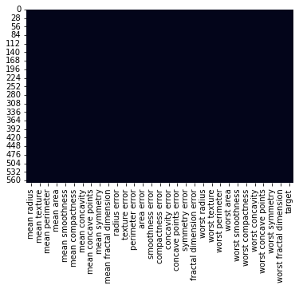

```python
sns.heatmap(inputData.isnull(), cbar=False)
```

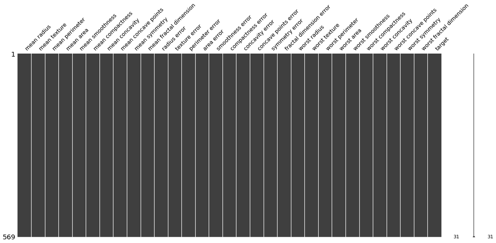

```python
msno.matrix(inputData)
```

```python
#Find number of missing cells in descending order
inputData.isnull().sum().sort_values(ascending=False)
```

```
mean radius                0
concavity error            0
worst fractal dimension    0
worst symmetry             0
worst concave points       0
worst concavity            0
worst compactness          0
worst smoothness           0
worst area                 0
worst perimeter            0
worst texture              0
worst radius               0
fractal dimension error    0
symmetry error             0
concave points error       0
compactness error          0
mean texture               0
smoothness error           0
area error                 0
perimeter error            0
texture error              0
radius error               0
mean fractal dimension     0
mean symmetry              0
mean concave points        0
mean concavity             0
mean compactness           0
mean smoothness            0
mean area                  0
mean perimeter             0
target                     0
dtype: int64
```

```python
#Find % of missing values in descending order
inputData.isnull().sum().sort_values(ascending=False)/len(inputData)
```

```
mean radius                0.0
concavity error            0.0
worst fractal dimension    0.0
worst symmetry             0.0
worst concave points       0.0
worst concavity            0.0
worst compactness          0.0
worst smoothness           0.0
worst area                 0.0
worst perimeter            0.0
worst texture              0.0
worst radius               0.0
fractal dimension error    0.0
symmetry error             0.0
concave points error       0.0
compactness error          0.0
mean texture               0.0
smoothness error           0.0
area error                 0.0
perimeter error            0.0
texture error              0.0
radius error               0.0
mean fractal dimension     0.0
mean symmetry              0.0
mean concave points        0.0
mean concavity             0.0
mean compactness           0.0
mean smoothness            0.0
mean area                  0.0
mean perimeter             0.0
target                     0.0
dtype: float64
```

### Conclusion: There are NO null values in any of the 31 columns of the dataframe

## 4.3 Check for duplicate rows

```python
# Selecting duplicate rows except first occurrence based on all columns
duplicateRows = inputData[inputData.duplicated()]
print("Duplicate Rows")
duplicateRows
```

```
Duplicate Rows
```

|  | mean radius | mean texture | mean perimeter | mean area | mean smoothness | mean compactness | mean concavity | mean concave points | mean symmetry | mean fractal dimension | ... | worst texture | worst perimeter | worst area | worst smoothness | worst compactness | worst concavity | worst concave points | worst symmetry | worst fractal dimension | target |
| --- | --- | --- | --- | --- | --- | --- | --- | --- | --- | --- | --- | --- | --- | --- | --- | --- | --- | --- | --- | --- | --- |

0 rows × 31 columns

### Conclusion: There are no duplicate rows

## 4.4 Check for duplicate columns

```python
# Selecting duplicate columns except first occurrence based on all rows
duplicateColumns = inputData.loc[:,inputData.apply(lambda x: x.duplicated(),axis=1).all()].copy()
print("Duplicate Columns")
duplicateColumns
```

```
Duplicate Columns
```

| 0 |
| --- |
| 1 |
| 2 |
| 3 |
| 4 |
| ... |
| 564 |
| 565 |
| 566 |
| 567 |
| 568 |

569 rows × 0 columns

```python
def getDuplicateColumns(df):
    '''
    Get a list of duplicate columns.
    It will iterate over all the columns in dataframe and find the columns whose contents are duplicate.
    :param df: Dataframe object
    :return: List of columns whose contents are duplicates.
    '''
    duplicateColumnNames = set()
    # Iterate over all the columns in dataframe
    for x in range(df.shape[1]):
        # Select column at xth index.
        col = df.iloc[:, x]
        # Iterate over all the columns in DataFrame from (x+1)th index till end
        for y in range(x + 1, df.shape[1]):
            # Select column at yth index.
            otherCol = df.iloc[:, y]
            # Check if two columns at x 7 y index are equal
            if col.equals(otherCol):
                duplicateColumnNames.add(df.columns.values[y])
    return list(duplicateColumnNames)

duplicateColumnNames = getDuplicateColumns(inputData)

#Print Duplicate Columns
duplicateColumnNames
```

```
[]
```

### Conclusion: There are no duplicate columns

## 4.5 Find Columns with Constant Data

```python
# Function to return the constant value columns of a given DataFrame
def remove_constant_value_features(df):
    return [e for e in df.columns if df[e].nunique() == 1]

drop_col = remove_constant_value_features(inputData)
drop_col

#inputData.columns[inputData1.nunique() <= 1]
```

```
[]
```

### Conclusion: There are no columns with constant data

## 4.6 Find Cells with Special Characters in Data Frame

```python
#Check if all but the last columns are float columns or integer columns. If they have special characters they will not be float type or integer type
inputData.dtypes
```

```
mean radius                float64
mean texture               float64
mean perimeter             float64
mean area                  float64
mean smoothness            float64
mean compactness           float64
mean concavity             float64
mean concave points        float64
mean symmetry              float64
mean fractal dimension     float64
radius error               float64
texture error              float64
perimeter error            float64
area error                 float64
smoothness error           float64
compactness error          float64
concavity error            float64
concave points error       float64
symmetry error             float64
fractal dimension error    float64
worst radius               float64
worst texture              float64
worst perimeter            float64
worst area                 float64
worst smoothness           float64
worst compactness          float64
worst concavity            float64
worst concave points       float64
worst symmetry             float64
worst fractal dimension    float64
target                     float64
dtype: object
```

### Conclusion: There are no special characters found as all columns are float

## 4.7 Find Cells with Special Characters or empty spaces in Data Frame Column Names

```python
# remove spaces in columns name
#unwanted = string.ascii_letters + string.punctuation + string.whitespace
#print(unwanted)
#df.col = df.col.str.strip(unwanted)
inputData.columns = inputData.columns.str.replace(' ','_')
unwanted = string.punctuation + string.whitespace
inputData.columns = inputData.columns.str.strip(unwanted)

#Check if all but the last columns are float columns or integer columns. If they have special characters they will not be float type or integer type
inputData.dtypes
```

```
mean_radius                float64
mean_texture               float64
mean_perimeter             float64
mean_area                  float64
mean_smoothness            float64
mean_compactness           float64
mean_concavity             float64
mean_concave_points        float64
mean_symmetry              float64
mean_fractal_dimension     float64
radius_error               float64
texture_error              float64
perimeter_error            float64
area_error                 float64
smoothness_error           float64
compactness_error          float64
concavity_error            float64
concave_points_error       float64
symmetry_error             float64
fractal_dimension_error    float64
worst_radius               float64
worst_texture              float64
worst_perimeter            float64
worst_area                 float64
worst_smoothness           float64
worst_compactness          float64
worst_concavity            float64
worst_concave_points       float64
worst_symmetry             float64
worst_fractal_dimension    float64
target                     float64
dtype: object
```

### Conclusion: Whitespaces were replaced with '_'

## 4.8 Check for correlation values via a heatmap

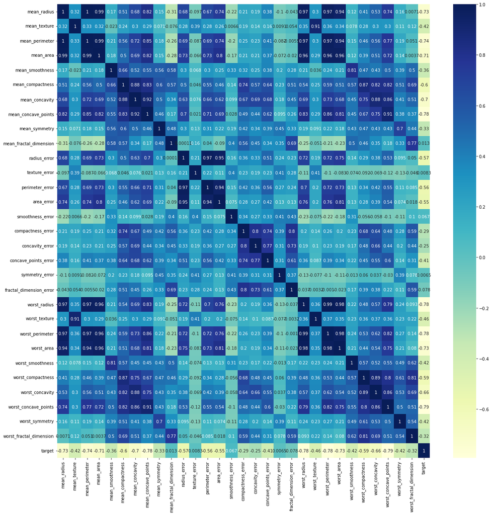

```python
fig, ax = plt.subplots(figsize=(20,20))         # Sample figsize in inches
dataplot = sns.heatmap(inputData.corr(), cmap="YlGnBu", annot=True, ax=ax)
```

```python
OriginalData = inputData.copy(deep=True)
inputData.drop(['mean_perimeter', 'mean_area', 'worst_radius', 'worst_perimeter', 'worst_area', 'perimeter_error', 'area_error'], axis=1, inplace=True)
inputDataPostHighCorrelationRemoval = inputData.copy(deep=True)
```

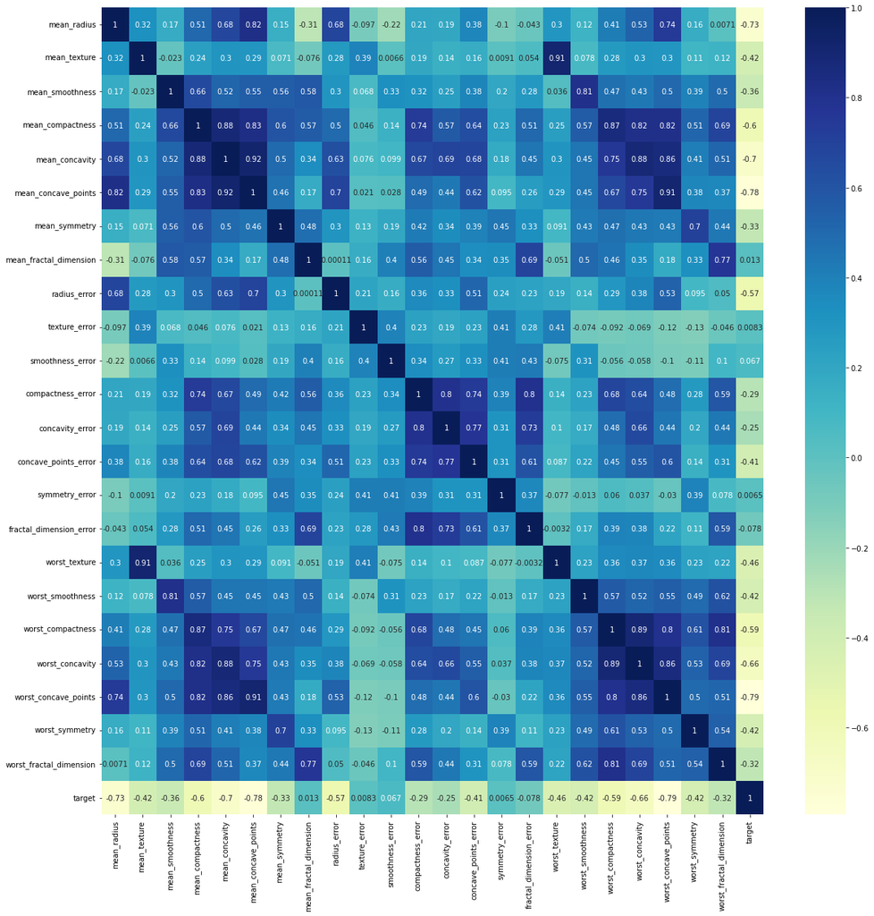

```python
#Let's redraw the correlation matrix to check of any other high correlations
fig, ax = plt.subplots(figsize=(20,20))         # Sample figsize in inches
dataplot = sns.heatmap(inputData.corr(), cmap="YlGnBu", annot=True, ax=ax)
```

## 4.9 Check for multi-collinearity

```python
def calc_vif(X):
    # Calculating VIF
    vif = pd.DataFrame()
    vif["variables"] = X.columns
    vif["VIF"] = [variance_inflation_factor(X.values, i) for i in range(X.shape[1])]
    return(vif)

#ensure you don't select 'Y' column i.e. Response
X = inputData.loc[:, ~inputData.columns.isin(['target'])]
calc_vif(X)
```

|  | variables | VIF |
| --- | --- | --- |
| 0 | mean_radius | 68.469737 |
| 1 | mean_texture | 239.997714 |
| 2 | mean_smoothness | 356.476788 |
| 3 | mean_compactness | 111.780757 |
| 4 | mean_concavity | 135.591708 |
| 5 | mean_concave_points | 137.540844 |
| 6 | mean_symmetry | 175.692683 |
| 7 | mean_fractal_dimension | 518.872775 |
| 8 | radius_error | 9.480204 |
| 9 | texture_error | 23.117234 |
| 10 | smoothness_error | 24.979795 |
| 11 | compactness_error | 43.060522 |
| 12 | concavity_error | 30.030151 |
| 13 | concave_points_error | 41.852887 |
| 14 | symmetry_error | 34.943192 |
| 15 | fractal_dimension_error | 24.904640 |
| 16 | worst_texture | 322.515709 |
| 17 | worst_smoothness | 365.328008 |
| 18 | worst_compactness | 123.409578 |
| 19 | worst_concavity | 83.063936 |
| 20 | worst_concave_points | 135.754144 |
| 21 | worst_symmetry | 205.754392 |
| 22 | worst_fractal_dimension | 403.321131 |

- VIF starts at 0 and has no upper limit
- VIF = 1, no correlation between the independent variable and the other variables
- 1 < VIF < 5, features are moderately correlated
- 5 < VIF < 10 or more, indicates high multicollinearity between this independent variable and the others
- VIF > 10, means high correlation between features and is cause for concern

We see that multiple Features have a VIF of 5 or more

We will remove parameters with high VIF scores one by one.

```python
inputData.drop(['mean_fractal_dimension'], axis=1, inplace=True)
```

```python
#ensure you don't select 'Y' column i.e. Response
X = inputData.loc[:, ~inputData.columns.isin(['target'])]
calc_vif(X)
```

|  | variables | VIF |
| --- | --- | --- |
| 0 | mean_radius | 61.552347 |
| 1 | mean_texture | 237.566355 |
| 2 | mean_smoothness | 324.046412 |
| 3 | mean_compactness | 102.081114 |
| 4 | mean_concavity | 133.610070 |
| 5 | mean_concave_points | 127.633603 |
| 6 | mean_symmetry | 170.772336 |
| 7 | radius_error | 9.333361 |
| 8 | texture_error | 22.990386 |
| 9 | smoothness_error | 24.966218 |
| 10 | compactness_error | 42.015726 |
| 11 | concavity_error | 29.751049 |
| 12 | concave_points_error | 41.845276 |
| 13 | symmetry_error | 34.533433 |
| 14 | fractal_dimension_error | 23.792834 |
| 15 | worst_texture | 320.803565 |
| 16 | worst_smoothness | 364.923293 |
| 17 | worst_compactness | 106.562302 |
| 18 | worst_concavity | 80.138704 |
| 19 | worst_concave_points | 135.648829 |
| 20 | worst_symmetry | 205.387076 |
| 21 | worst_fractal_dimension | 191.745893 |

```python
inputData.drop(['worst_smoothness'], axis=1, inplace=True)
```

```python
#ensure you don't select 'Y' column i.e. Response
X = inputData.loc[:, ~inputData.columns.isin(['target'])]
calc_vif(X)
```

|  | variables | VIF |
| --- | --- | --- |
| 0 | mean_radius | 61.059053 |
| 1 | mean_texture | 227.189396 |
| 2 | mean_smoothness | 140.743892 |
| 3 | mean_compactness | 102.078907 |
| 4 | mean_concavity | 133.510979 |
| 5 | mean_concave_points | 124.236958 |
| 6 | mean_symmetry | 167.553684 |
| 7 | radius_error | 9.297943 |
| 8 | texture_error | 22.271007 |
| 9 | smoothness_error | 13.856606 |
| 10 | compactness_error | 41.773787 |
| 11 | concavity_error | 29.749996 |
| 12 | concave_points_error | 40.772374 |
| 13 | symmetry_error | 32.954888 |
| 14 | fractal_dimension_error | 23.696820 |
| 15 | worst_texture | 298.869570 |
| 16 | worst_compactness | 106.389358 |
| 17 | worst_concavity | 80.090766 |
| 18 | worst_concave_points | 123.870205 |
| 19 | worst_symmetry | 197.410288 |
| 20 | worst_fractal_dimension | 185.567373 |

```python
inputData.drop(['worst_texture'], axis=1, inplace=True)
```

```python
#ensure you don't select 'Y' column i.e. Response
X = inputData.loc[:, ~inputData.columns.isin(['target'])]
calc_vif(X)
```

|  | variables | VIF |
| --- | --- | --- |
| 0 | mean_radius | 60.773662 |
| 1 | mean_texture | 34.873524 |
| 2 | mean_smoothness | 140.094247 |
| 3 | mean_compactness | 101.945812 |
| 4 | mean_concavity | 133.480943 |
| 5 | mean_concave_points | 123.190199 |
| 6 | mean_symmetry | 155.835314 |
| 7 | radius_error | 9.297158 |
| 8 | texture_error | 12.193240 |
| 9 | smoothness_error | 13.855847 |
| 10 | compactness_error | 41.683460 |
| 11 | concavity_error | 29.714509 |
| 12 | concave_points_error | 39.113833 |
| 13 | symmetry_error | 26.883017 |
| 14 | fractal_dimension_error | 23.671117 |
| 15 | worst_compactness | 106.353058 |
| 16 | worst_concavity | 80.076988 |
| 17 | worst_concave_points | 116.795661 |
| 18 | worst_symmetry | 163.663716 |
| 19 | worst_fractal_dimension | 185.563041 |

```python
inputData.drop(['worst_fractal_dimension'], axis=1, inplace=True)
```

```python
#ensure you don't select 'Y' column i.e. Response
X = inputData.loc[:, ~inputData.columns.isin(['target'])]
calc_vif(X)
```

|  | variables | VIF |
| --- | --- | --- |
| 0 | mean_radius | 58.780948 |
| 1 | mean_texture | 34.265055 |
| 2 | mean_smoothness | 105.487652 |
| 3 | mean_compactness | 101.945673 |
| 4 | mean_concavity | 133.473470 |
| 5 | mean_concave_points | 116.396927 |
| 6 | mean_symmetry | 154.919045 |
| 7 | radius_error | 9.261511 |
| 8 | texture_error | 12.192736 |
| 9 | smoothness_error | 13.754691 |
| 10 | compactness_error | 39.018297 |
| 11 | concavity_error | 29.203555 |
| 12 | concave_points_error | 39.097489 |
| 13 | symmetry_error | 26.446967 |
| 14 | fractal_dimension_error | 12.292740 |
| 15 | worst_compactness | 91.881849 |
| 16 | worst_concavity | 78.522846 |
| 17 | worst_concave_points | 116.775109 |
| 18 | worst_symmetry | 160.693770 |

```python
inputData.drop(['worst_symmetry'], axis=1, inplace=True)
```

```python
#ensure you don't select 'Y' column i.e. Response
X = inputData.loc[:, ~inputData.columns.isin(['target'])]
calc_vif(X)
```

|  | variables | VIF |
| --- | --- | --- |
| 0 | mean_radius | 58.772774 |
| 1 | mean_texture | 33.876602 |
| 2 | mean_smoothness | 104.905788 |
| 3 | mean_compactness | 98.952933 |
| 4 | mean_concavity | 132.961686 |
| 5 | mean_concave_points | 115.870250 |
| 6 | mean_symmetry | 82.062872 |
| 7 | radius_error | 9.021928 |
| 8 | texture_error | 11.579233 |
| 9 | smoothness_error | 13.566153 |
| 10 | compactness_error | 37.892066 |
| 11 | concavity_error | 28.398864 |
| 12 | concave_points_error | 35.204433 |
| 13 | symmetry_error | 13.885790 |
| 14 | fractal_dimension_error | 12.291382 |
| 15 | worst_compactness | 83.865680 |
| 16 | worst_concavity | 78.317096 |
| 17 | worst_concave_points | 102.600633 |

```python
inputData.drop(['mean_concavity'], axis=1, inplace=True)
```

```python
#ensure you don't select 'Y' column i.e. Response
X = inputData.loc[:, ~inputData.columns.isin(['target'])]
calc_vif(X)
```

|  | variables | VIF |
| --- | --- | --- |
| 0 | mean_radius | 58.287447 |
| 1 | mean_texture | 33.847312 |
| 2 | mean_smoothness | 98.452269 |
| 3 | mean_compactness | 83.971325 |
| 4 | mean_concave_points | 48.464070 |
| 5 | mean_symmetry | 81.950723 |
| 6 | radius_error | 8.793975 |
| 7 | texture_error | 11.545356 |
| 8 | smoothness_error | 13.315233 |
| 9 | compactness_error | 37.574524 |
| 10 | concavity_error | 21.540275 |
| 11 | concave_points_error | 33.636944 |
| 12 | symmetry_error | 13.885132 |
| 13 | fractal_dimension_error | 12.290575 |
| 14 | worst_compactness | 80.872930 |
| 15 | worst_concavity | 53.113883 |
| 16 | worst_concave_points | 94.374385 |

```python
inputData.drop(['mean_smoothness'], axis=1, inplace=True)
```

```python
#ensure you don't select 'Y' column i.e. Response
X = inputData.loc[:, ~inputData.columns.isin(['target'])]
calc_vif(X)
```

|  | variables | VIF |
| --- | --- | --- |
| 0 | mean_radius | 50.353844 |
| 1 | mean_texture | 33.716109 |
| 2 | mean_compactness | 72.990769 |
| 3 | mean_concave_points | 46.005811 |
| 4 | mean_symmetry | 59.937504 |
| 5 | radius_error | 8.625745 |
| 6 | texture_error | 11.406287 |
| 7 | smoothness_error | 10.300253 |
| 8 | compactness_error | 33.292206 |
| 9 | concavity_error | 21.535114 |
| 10 | concave_points_error | 33.492574 |
| 11 | symmetry_error | 13.852207 |
| 12 | fractal_dimension_error | 11.986375 |
| 13 | worst_compactness | 80.863443 |
| 14 | worst_concavity | 53.112823 |
| 15 | worst_concave_points | 94.046109 |

```python
inputData.drop(['worst_concave_points'], axis=1, inplace=True)
```

```python
#ensure you don't select 'Y' column i.e. Response
X = inputData.loc[:, ~inputData.columns.isin(['target'])]
calc_vif(X)
```

|  | variables | VIF |
| --- | --- | --- |
| 0 | mean_radius | 48.175383 |
| 1 | mean_texture | 33.633524 |
| 2 | mean_compactness | 69.522936 |
| 3 | mean_concave_points | 30.448538 |
| 4 | mean_symmetry | 59.508377 |
| 5 | radius_error | 8.445487 |
| 6 | texture_error | 11.083013 |
| 7 | smoothness_error | 10.255197 |
| 8 | compactness_error | 29.617428 |
| 9 | concavity_error | 20.606324 |
| 10 | concave_points_error | 19.847315 |
| 11 | symmetry_error | 13.785579 |
| 12 | fractal_dimension_error | 11.955077 |
| 13 | worst_compactness | 66.212385 |
| 14 | worst_concavity | 49.451486 |

```python
inputData.drop(['mean_compactness'], axis=1, inplace=True)
```

```python
#ensure you don't select 'Y' column i.e. Response
X = inputData.loc[:, ~inputData.columns.isin(['target'])]
calc_vif(X)
```

|  | variables | VIF |
| --- | --- | --- |
| 0 | mean_radius | 45.447978 |
| 1 | mean_texture | 33.617536 |
| 2 | mean_concave_points | 17.182508 |
| 3 | mean_symmetry | 51.495644 |
| 4 | radius_error | 8.426110 |
| 5 | texture_error | 11.078230 |
| 6 | smoothness_error | 10.188141 |
| 7 | compactness_error | 29.212994 |
| 8 | concavity_error | 20.514755 |
| 9 | concave_points_error | 19.847264 |
| 10 | symmetry_error | 13.768024 |
| 11 | fractal_dimension_error | 11.809791 |
| 12 | worst_compactness | 49.587923 |
| 13 | worst_concavity | 47.185157 |

```python
inputData.drop(['mean_symmetry'], axis=1, inplace=True)
```

```python
#ensure you don't select 'Y' column i.e. Response
X = inputData.loc[:, ~inputData.columns.isin(['target'])]
calc_vif(X)
```

|  | variables | VIF |
| --- | --- | --- |
| 0 | mean_radius | 33.799478 |
| 1 | mean_texture | 33.302650 |
| 2 | mean_concave_points | 16.626897 |
| 3 | radius_error | 8.223314 |
| 4 | texture_error | 11.061240 |
| 5 | smoothness_error | 9.414116 |
| 6 | compactness_error | 25.761052 |
| 7 | concavity_error | 20.477246 |
| 8 | concave_points_error | 19.338629 |
| 9 | symmetry_error | 10.103862 |
| 10 | fractal_dimension_error | 11.253291 |
| 11 | worst_compactness | 43.963725 |
| 12 | worst_concavity | 46.858354 |

```python
inputData.drop(['worst_concavity'], axis=1, inplace=True)
```

```python
#ensure you don't select 'Y' column i.e. Response
X = inputData.loc[:, ~inputData.columns.isin(['target'])]
calc_vif(X)
```

|  | variables | VIF |
| --- | --- | --- |
| 0 | mean_radius | 33.799351 |
| 1 | mean_texture | 33.104857 |
| 2 | mean_concave_points | 13.401367 |
| 3 | radius_error | 8.183043 |
| 4 | texture_error | 11.059027 |
| 5 | smoothness_error | 9.409189 |
| 6 | compactness_error | 22.805896 |
| 7 | concavity_error | 8.060327 |
| 8 | concave_points_error | 18.262886 |
| 9 | symmetry_error | 9.941383 |
| 10 | fractal_dimension_error | 10.753478 |
| 11 | worst_compactness | 14.689947 |

```python
inputData.drop(['mean_texture'], axis=1, inplace=True)
```

```python
#ensure you don't select 'Y' column i.e. Response
X = inputData.loc[:, ~inputData.columns.isin(['target'])]
calc_vif(X)
```

|  | variables | VIF |
| --- | --- | --- |
| 0 | mean_radius | 16.962850 |
| 1 | mean_concave_points | 11.683209 |
| 2 | radius_error | 8.176904 |
| 3 | texture_error | 7.867147 |
| 4 | smoothness_error | 9.236729 |
| 5 | compactness_error | 22.507730 |
| 6 | concavity_error | 8.040346 |
| 7 | concave_points_error | 18.262626 |
| 8 | symmetry_error | 9.899820 |
| 9 | fractal_dimension_error | 10.752441 |
| 10 | worst_compactness | 12.542107 |

```python
inputData.drop(['compactness_error'], axis=1, inplace=True)
```

```python
#ensure you don't select 'Y' column i.e. Response
X = inputData.loc[:, ~inputData.columns.isin(['target'])]
calc_vif(X)
```

|  | variables | VIF |
| --- | --- | --- |
| 0 | mean_radius | 15.086320 |
| 1 | mean_concave_points | 11.641811 |
| 2 | radius_error | 8.034708 |
| 3 | texture_error | 7.863316 |
| 4 | smoothness_error | 9.236604 |
| 5 | concavity_error | 7.365311 |
| 6 | concave_points_error | 16.986837 |
| 7 | symmetry_error | 9.702738 |
| 8 | fractal_dimension_error | 8.381498 |
| 9 | worst_compactness | 8.268082 |

```python
inputData.drop(['concave_points_error'], axis=1, inplace=True)
```

```python
#ensure you don't select 'Y' column i.e. Response
X = inputData.loc[:, ~inputData.columns.isin(['target'])]
calc_vif(X)
```

|  | variables | VIF |
| --- | --- | --- |
| 0 | mean_radius | 14.394159 |
| 1 | mean_concave_points | 10.704607 |
| 2 | radius_error | 8.030618 |
| 3 | texture_error | 7.838053 |
| 4 | smoothness_error | 8.821710 |
| 5 | concavity_error | 5.322736 |
| 6 | symmetry_error | 9.664001 |
| 7 | fractal_dimension_error | 8.228919 |
| 8 | worst_compactness | 8.176955 |

```python
inputData.drop(['mean_radius'], axis=1, inplace=True)
```

```python
#ensure you don't select 'Y' column i.e. Response
X = inputData.loc[:, ~inputData.columns.isin(['target'])]
calc_vif(X)
```

|  | variables | VIF |
| --- | --- | --- |
| 0 | mean_concave_points | 9.892429 |
| 1 | radius_error | 7.527503 |
| 2 | texture_error | 7.294895 |
| 3 | smoothness_error | 8.401561 |
| 4 | concavity_error | 5.229743 |
| 5 | symmetry_error | 9.178768 |
| 6 | fractal_dimension_error | 8.016030 |
| 7 | worst_compactness | 7.218366 |

```python
inputData.drop(['mean_concave_points'], axis=1, inplace=True)
```

```python
#ensure you don't select 'Y' column i.e. Response
X = inputData.loc[:, ~inputData.columns.isin(['target'])]
calc_vif(X)
```

|  | variables | VIF |
| --- | --- | --- |
| 0 | radius_error | 3.845192 |
| 1 | texture_error | 7.263145 |
| 2 | smoothness_error | 8.401451 |
| 3 | concavity_error | 5.069481 |
| 4 | symmetry_error | 9.030783 |
| 5 | fractal_dimension_error | 7.799080 |
| 6 | worst_compactness | 4.091986 |

```python
inputData.drop(['symmetry_error'], axis=1, inplace=True)
```

```python
#ensure you don't select 'Y' column i.e. Response
X = inputData.loc[:, ~inputData.columns.isin(['target'])]
calc_vif(X)
```

|  | variables | VIF |
| --- | --- | --- |
| 0 | radius_error | 3.770520 |
| 1 | texture_error | 6.130460 |
| 2 | smoothness_error | 7.176174 |
| 3 | concavity_error | 5.069041 |
| 4 | fractal_dimension_error | 7.754716 |
| 5 | worst_compactness | 3.971687 |

```python
inputData.drop(['fractal_dimension_error'], axis=1, inplace=True)
```

```python
#ensure you don't select 'Y' column i.e. Response
X = inputData.loc[:, ~inputData.columns.isin(['target'])]
calc_vif(X)
```

|  | variables | VIF |
| --- | --- | --- |
| 0 | radius_error | 3.723257 |
| 1 | texture_error | 6.041503 |
| 2 | smoothness_error | 6.286196 |
| 3 | concavity_error | 3.098950 |
| 4 | worst_compactness | 3.830757 |

```python
inputData.drop(['smoothness_error'], axis=1, inplace=True)
```

```python
#ensure you don't select 'Y' column i.e. Response
X = inputData.loc[:, ~inputData.columns.isin(['target'])]
calc_vif(X)
```

|  | variables | VIF |
| --- | --- | --- |
| 0 | radius_error | 3.654194 |
| 1 | texture_error | 3.266426 |
| 2 | concavity_error | 3.027385 |
| 3 | worst_compactness | 3.764800 |

### Conclusion: Post improvement for Multi-collinearity, we are left with four features

## 4.10 Check for Outliers

```
<class 'pandas.core.frame.DataFrame'>
RangeIndex: 569 entries, 0 to 568
Data columns (total 5 columns):
 #   Column             Non-Null Count  Dtype
---  ------             --------------  -----
 0   radius_error       569 non-null    float64
 1   texture_error      569 non-null    float64
 2   concavity_error    569 non-null    float64
 3   worst_compactness  569 non-null    float64
 4   target             569 non-null    float64
dtypes: float64(5)
memory usage: 22.4 KB
```

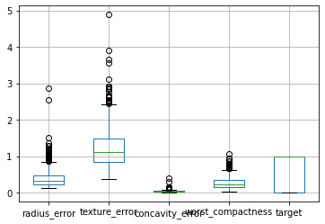

```python
# Plot outliers in box plot for X variables
# boxplot = inputData.boxplot(column=inputData.columns['Distance', 'Cost','Discount','Delivery charges','Surge charges','Packaging charges','ST','Tip'])
dfBoxPlot=inputData.select_dtypes(include='number')
dfBoxPlot.info()
boxplot = dfBoxPlot.boxplot(column=dfBoxPlot.columns.values.tolist())#[ :-1]
```

### Conclusion: There are outliers in all the 4 Features

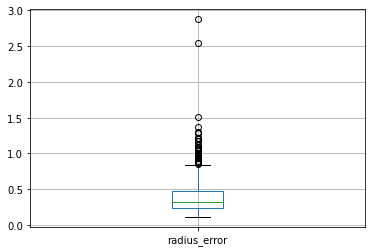

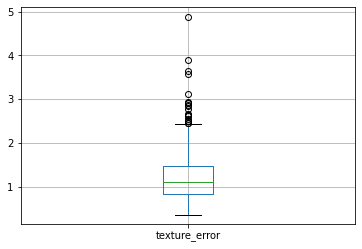

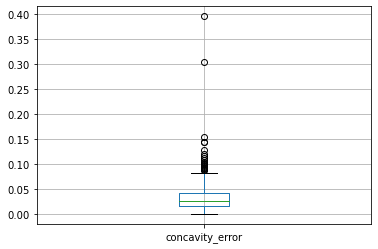

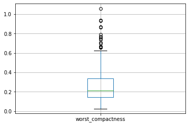

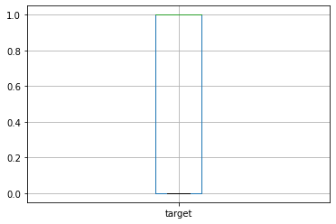

```python
for col in dfBoxPlot:
    plt.figure()
    dfBoxPlot.boxplot(column=[col])
```

```python
#remove outliers using IQR Range basis guidance from NIST
#https://www.itl.nist.gov/div898/handbook/prc/section1/prc16.htm

inputDataPlay=inputData.copy(deep=True)
inputDataPlay.info(verbose=True,memory_usage='deep',show_counts=True)

col_name = inputDataPlay.select_dtypes(include='number').columns.values.tolist()

Q1 = inputDataPlay[col_name].quantile(0.25)
Q3 = inputDataPlay[col_name].quantile(0.75)
IQR = Q3 - Q1
lower_boundary = Q1 - (1.5 * IQR)
upper_boundary = Q3 + (1.5 * IQR)

for column in col_name:
    inputDataPlay = inputDataPlay[inputDataPlay[column] >= lower_boundary[column]]
    inputDataPlay = inputDataPlay[inputDataPlay[column] <= upper_boundary[column]]

#print(df)
inputDataPlay.info(verbose=True,memory_usage='deep',show_counts=True)
inputDataPlay.describe(include='all')
```

```
<class 'pandas.core.frame.DataFrame'>
RangeIndex: 569 entries, 0 to 568
Data columns (total 5 columns):
 #   Column             Non-Null Count  Dtype
---  ------             --------------  -----
 0   radius_error       569 non-null    float64
 1   texture_error      569 non-null    float64
 2   concavity_error    569 non-null    float64
 3   worst_compactness  569 non-null    float64
 4   target             569 non-null    float64
dtypes: float64(5)
memory usage: 22.4 KB
<class 'pandas.core.frame.DataFrame'>
Int64Index: 488 entries, 1 to 568
Data columns (total 5 columns):
 #   Column             Non-Null Count  Dtype
---  ------             --------------  -----
 0   radius_error       488 non-null    float64
 1   texture_error      488 non-null    float64
 2   concavity_error    488 non-null    float64
 3   worst_compactness  488 non-null    float64
 4   target             488 non-null    float64
dtypes: float64(5)
memory usage: 22.9 KB
```

|  | radius_error | texture_error | concavity_error | worst_compactness | target |
| --- | --- | --- | --- | --- | --- |
| count | 488.000000 | 488.000000 | 488.000000 | 488.000000 | 488.000000 |
| mean | 0.345968 | 1.135762 | 0.026088 | 0.230858 | 0.680328 |
| std | 0.166182 | 0.432897 | 0.016501 | 0.124109 | 0.466828 |
| min | 0.114400 | 0.360200 | 0.000000 | 0.034320 | 0.000000 |
| 25% | 0.224050 | 0.811525 | 0.014040 | 0.140100 | 0.000000 |
| 50% | 0.298200 | 1.059000 | 0.022800 | 0.202050 | 1.000000 |
| 75% | 0.421400 | 1.392750 | 0.035930 | 0.304825 | 1.000000 |
| max | 0.842600 | 2.426000 | 0.081580 | 0.624700 | 1.000000 |

```
<class 'pandas.core.frame.DataFrame'>
Int64Index: 488 entries, 1 to 568
Data columns (total 5 columns):
 #   Column             Non-Null Count  Dtype
---  ------             --------------  -----
 0   radius_error       488 non-null    float64
 1   texture_error      488 non-null    float64
 2   concavity_error    488 non-null    float64
 3   worst_compactness  488 non-null    float64
 4   target             488 non-null    float64
dtypes: float64(5)
memory usage: 22.9 KB
```

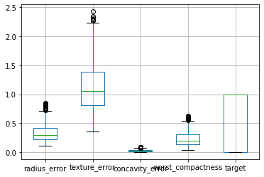

```python
dfBoxPlot=inputDataPlay.select_dtypes(include='number')
dfBoxPlot.info()
boxplot = dfBoxPlot.boxplot(column=dfBoxPlot.columns.values.tolist())#[ :-1]
```

### Conclusion: The number of outliers have reduced and overall count of data points has now reduced from 569 to 488

## 4.11 Visualize distribution of target classes

### 4.11.1 Check for Data Balance

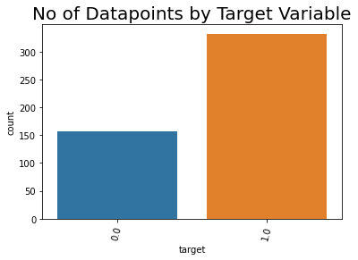

```python
plt.title('No of Datapoints by Target Variable',fontsize=20)
sns.countplot(inputDataPlay.target)
plt.xticks(rotation=75)
plt.show()
```

### Conclusion: There seems to be a class imbalance. This can be corrected using Synthetic Minority Oversampling Technique (SMOTE).

### 4.11.2 Visualize Target Variable basis radius_error

[figure not shown]

```python
ax = sns.countplot("radius_error", hue="target", data=inputDataPlay)
for p in ax.patches:
    ax.annotate('{:.0f}'.format(p.get_height()), (p.get_x()+0.10, p.get_height()+1))
plt.show()
```

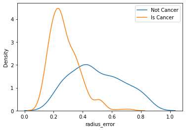

```python
# kernel-density plot
sns.kdeplot(inputDataPlay.radius_error[inputDataPlay.target == 0])
sns.kdeplot(inputDataPlay.radius_error[inputDataPlay.target == 1])
plt.legend(["Not Cancer","Is Cancer"])
plt.xlabel("radius_error")
plt.rcParams.update({'figure.figsize':(5,4), 'figure.dpi':100})
plt.show()
```

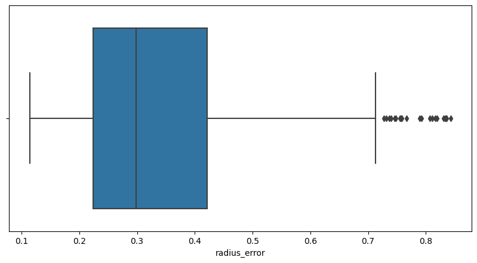

```python
plt.figure(figsize =(10,5))
sns.boxplot("radius_error", data=inputDataPlay)
plt.show()
```

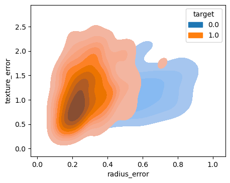

```python
sns.kdeplot(
    data=inputDataPlay, x="radius_error", y="texture_error", hue="target", fill=True,
)
```

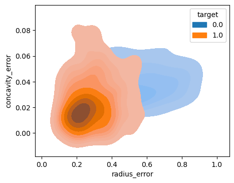

```python
sns.kdeplot(
    data=inputDataPlay, x="radius_error", y="concavity_error", hue="target", fill=True,
)
```

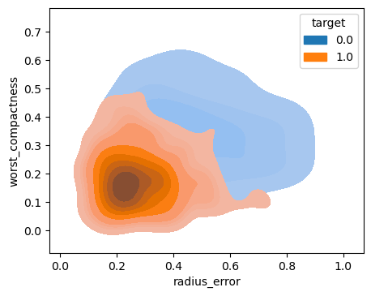

```python
sns.kdeplot(
    data=inputDataPlay, x="radius_error", y="worst_compactness", hue="target", fill=True,
)
```

### Conclusion: Cancer seems to be due to an interaction effect between 2 or more Features basis the KDE Plot

### 4.11.3 Visualize Target Variable basis texture_error

[figure not shown]

```python
ax = sns.countplot("texture_error", hue="target", data=inputDataPlay)
for p in ax.patches:
    ax.annotate('{:.0f}'.format(p.get_height()), (p.get_x()+0.10, p.get_height()+1))
plt.show()
```

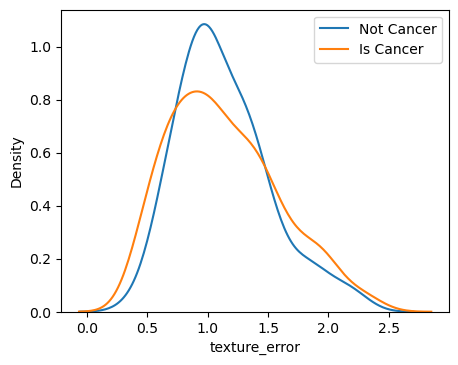

```python
# kernel-density plot
sns.kdeplot(inputDataPlay.texture_error[inputDataPlay.target == 0])
sns.kdeplot(inputDataPlay.texture_error[inputDataPlay.target == 1])
plt.legend(["Not Cancer","Is Cancer"])
plt.xlabel("texture_error")
plt.rcParams.update({'figure.figsize':(5,4), 'figure.dpi':100})
plt.show()
```

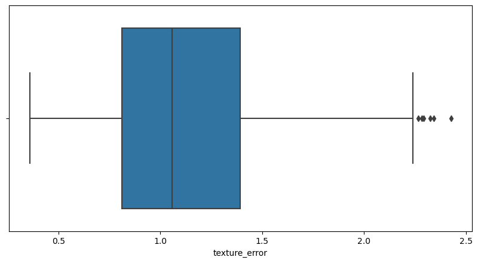

```python
plt.figure(figsize =(10,5))
sns.boxplot("texture_error", data=inputDataPlay)
plt.show()
```

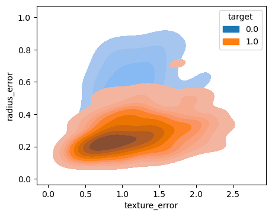

```python
sns.kdeplot(
    data=inputDataPlay, x="texture_error", y="radius_error", hue="target", fill=True,
)
```

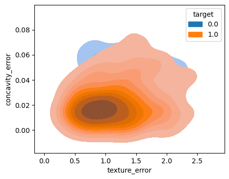

```python
sns.kdeplot(
    data=inputDataPlay, x="texture_error", y="concavity_error", hue="target", fill=True,
)
```

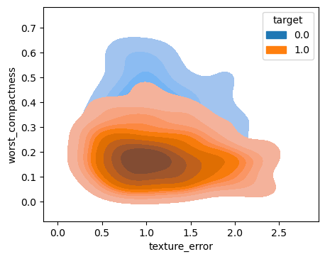

```python
sns.kdeplot(
    data=inputDataPlay, x="texture_error", y="worst_compactness", hue="target", fill=True,
)
```

### Conclusion: Cancer seems to be due to an interaction effect between 2 or more Features basis the KDE Plot

### 4.11.4 Visualize Target Variable basis concavity_error

[figure not shown]

```python
ax = sns.countplot("concavity_error", hue="target", data=inputDataPlay)
for p in ax.patches:
    ax.annotate('{:.0f}'.format(p.get_height()), (p.get_x()+0.10, p.get_height()+1))
plt.show()
```

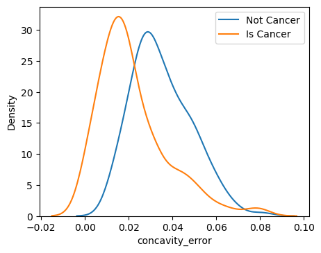

```python
# kernel-density plot
sns.kdeplot(inputDataPlay.concavity_error[inputDataPlay.target == 0])
sns.kdeplot(inputDataPlay.concavity_error[inputDataPlay.target == 1])
plt.legend(["Not Cancer","Is Cancer"])
plt.xlabel("concavity_error")
plt.rcParams.update({'figure.figsize':(5,4), 'figure.dpi':100})
plt.show()
```

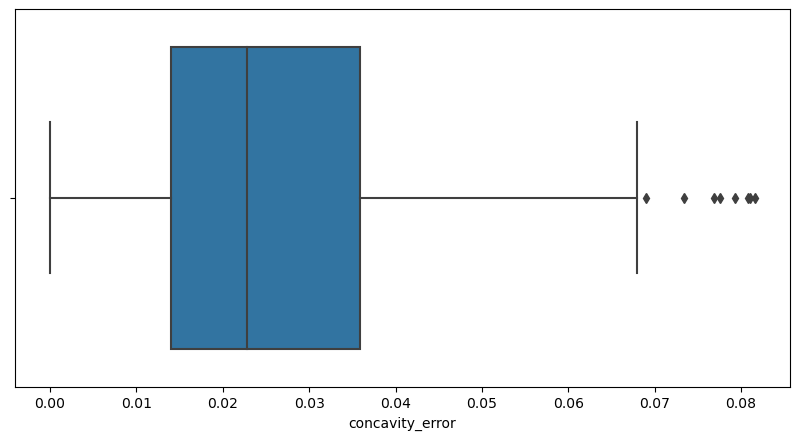

```python
plt.figure(figsize =(10,5))
sns.boxplot("concavity_error", data=inputDataPlay)
plt.show()
```

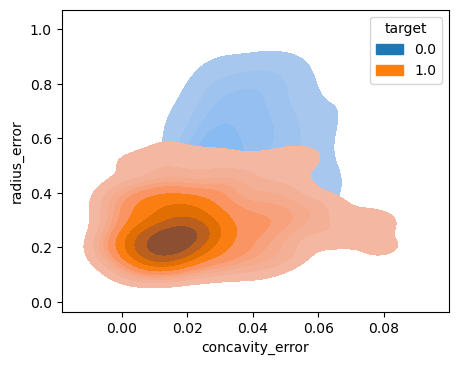

```python
sns.kdeplot(
    data=inputDataPlay, x="concavity_error", y="radius_error", hue="target", fill=True,
)
```

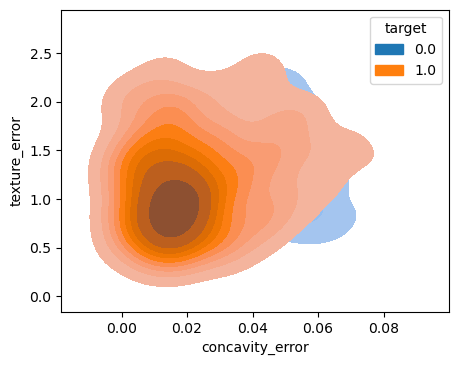

```python
sns.kdeplot(
    data=inputDataPlay, x="concavity_error", y="texture_error", hue="target", fill=True,
)
```

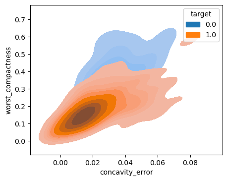

```python
sns.kdeplot(
    data=inputDataPlay, x="concavity_error", y="worst_compactness", hue="target", fill=True,
)
```

### Conclusion: Cancer seems to be due to an interaction effect between 2 or more Features basis the KDE Plot